# Mapping Antimicrobial Resistance Across U.S. States

## 10.1

[figure not shown]

# 11 Part 6 — Is there a seasonal pattern?

Small multiples don’t have to be organized by year — the same technique works for any repeating unit of time. Here we’ll look at *season*, using all eight years pooled together so each panel has enough data behind it to be worth looking at.

## 11.1 6a. Start non-spatial: what does the distribution look like?

Before mapping anything, look at the plain distribution. Pooling across 2018-2025 gives us enough isolates per month to see a shape, where any single year would mostly be noise.

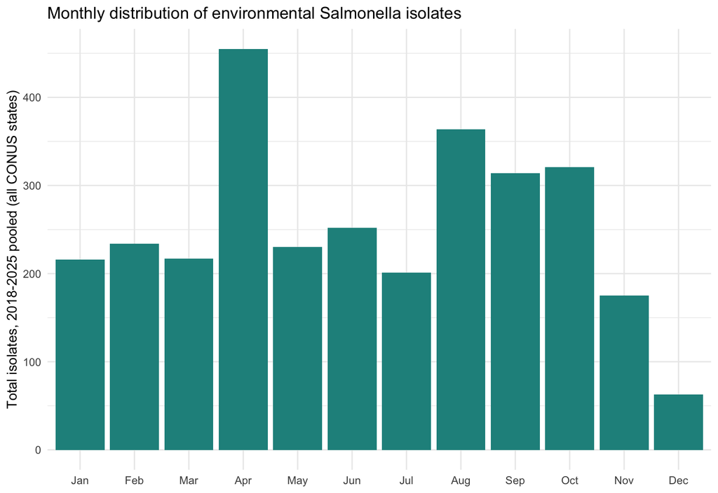

```r
monthly_totals <- beam %>%
  filter(source_type == "Environment", pathogen == "Salmonella",
         year >= 2018, year <= 2025,
         state %in% valid_state_codes) %>%
  group_by(month) %>%
  summarize(isolates = sum(number_of_isolates, na.rm = TRUE), .groups = "drop")

ggplot(monthly_totals, aes(x = factor(month), y = isolates)) +
  geom_col(fill = "#21908CFF") +
  scale_x_discrete(labels = month.abb) +
  labs(x = NULL, y = "Total isolates, 2018-2025 pooled (all CONUS states)",
       title = "Monthly distribution of environmental Salmonella isolates") +
  theme_minimal()
```

**Discussion:** Does this look seasonal to you, or does it look close to flat with some noise? What would make you more confident either way — more years, more states, or something else?

## 11.2 6b. Now map the same idea

Group the same eight years of data into four seasons per state, so we can see whether the pattern in 6a is broadly shared across the country or driven by a handful of states.

```r
season_levels <- c("Winter (Dec-Feb)", "Spring (Mar-May)",
                    "Summer (Jun-Aug)", "Fall (Sep-Nov)")

beam_season <- beam %>%
  filter(source_type == "Environment", pathogen == "Salmonella",
         year >= 2018, year <= 2025,
         state %in% valid_state_codes) %>%
  mutate(season = case_when(
    month %in% c(12, 1, 2)  ~ "Winter (Dec-Feb)",
    month %in% c(3, 4, 5)   ~ "Spring (Mar-May)",
    month %in% c(6, 7, 8)   ~ "Summer (Jun-Aug)",
    month %in% c(9, 10, 11) ~ "Fall (Sep-Nov)"
  )) %>%
  group_by(state, season) %>%
  summarize(isolates = sum(number_of_isolates, na.rm = TRUE), .groups = "drop")

season_panel <- expand_grid(stusps = states_conus$stusps, season = season_levels) %>%
  left_join(beam_season, by = c("stusps" = "state", "season")) %>%
  mutate(isolates = coalesce(isolates, 0),
         season = factor(season, levels = season_levels))

season_sf <- states_conus %>%
  select(stusps, geometry) %>%
  left_join(season_panel, by = "stusps")
```

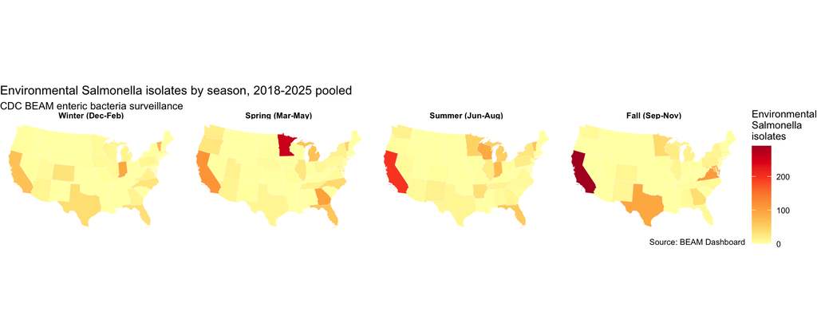

```r
ggplot(season_sf) +
  geom_sf(aes(fill = isolates), color = "white", linewidth = 0.05) +
  facet_wrap(~ season, nrow = 1) +
  scale_fill_distiller(palette = "YlOrRd",  direction = 1,
                       name = "Environmental\nSalmonella\nisolates",
                        limits = c(0, max(season_sf$isolates))) +
  theme_void(base_size = 9) +
  theme(strip.text = element_text(face = "bold")) +
  labs(title = "Environmental Salmonella isolates by season, 2018-2025 pooled",
       subtitle = "CDC BEAM enteric bacteria surveillance",
       caption = "Source: BEAM Dashboard")
```

**Discussion prompts:**

1. *Salmonella* survival and growth in water and soil is generally understood to be temperature-dependent, which would predict a warm-season peak. Does the summer panel support that here? Before you answer yes, go back to the surveillance-effort caution from Part 1b and Part 5 — what competing explanation do you need to rule out first?
2. Are the same states lighting up in Part 5’s year panels and this season panel? A state that’s consistently high across all seasons is telling you a different story than a state that’s high in exactly one season.
3. Why did we pool eight years into four seasons instead of mapping, say, just August 2024 across all states? (Look back at how sparse the single-year, single-month cells would have been.)

# 12 Part 7 — Linking the environmental signal to the clinical outcome

Now the environmental pharmacoepi question: is a state’s environmental surveillance signal for *Salmonella* associated with its clinical MDR *E. coli* burden? We’ll use the full 2018-2025 total this time as we just saw in parts 5-6 just a single year can be noisy.

```r
env_total <- beam_panel %>%
  group_by(stusps) %>%
  summarize(env_isolates_total = sum(isolates), .groups = "drop")

sum(env_total$env_isolates_total == 0)   # states with zero isolates, 2018-2025 combined
```

```
## [1] 14
```

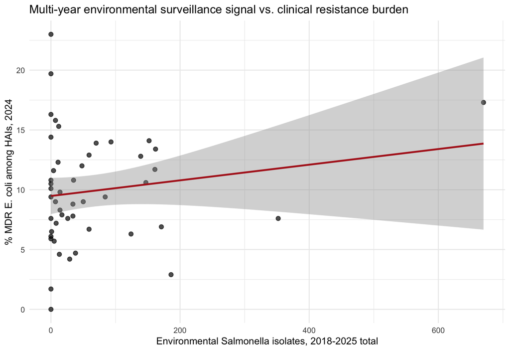

```r
plot_df <- map_data %>%
  st_drop_geometry() %>%
  left_join(env_total, by = "stusps")

ggplot(plot_df, aes(x = env_isolates_total, y = percent_resistant)) +
  geom_point(size = 2, alpha = 0.7) +
  geom_smooth(method = "lm", se = TRUE, color = "firebrick") +
  labs(x = "Environmental Salmonella isolates, 2018-2025 total",
       y = "% MDR E. coli among HAIs, 2024",
       title = "Multi-year environmental surveillance signal vs. clinical resistance burden") +
  theme_minimal()
```

```r
cor.test(plot_df$env_isolates_total, plot_df$percent_resistant, method = "spearman")
```

```
##
##  Spearman's rank correlation rho
##
## data:  plot_df$env_isolates_total and plot_df$percent_resistant
## S = 17350, p-value = 0.6938
## alternative hypothesis: true rho is not equal to 0
## sample estimates:
##        rho
## 0.05831997
```

**Discussion of the exercise. Work through it as a group.**

1. Is there a correlation? Is it what you expected? Compare the number of zero-isolate states here (pooling eight years) to the single-year 2024 map from Part 4 — pooling helped, but did it fully solve the surveillance-effort problem, or just shrink it?
2. This is still **surveillance/detection bias**: an “exposure” built from surveillance counts is measuring exposure *and* testing effort at the same time, and you generally can’t fully separate the two from counts alone.
3. Both variables here are aggregated to the *state* level, an administrative boundary chosen for governance, not for epidemiology. Two pieces of jargon worth knowing cold for this field:
   - **Ecological fallacy**: even if the correlation above is real, it tells you nothing about *individual* patients — you cannot conclude that a specific person’s resistant infection was caused by environmental exposure just because their state shows an association.
   - **Modifiable Areal Unit Problem (MAUP)**: had we aggregated to counties, HHS regions, or watersheds instead of states, both the magnitude and even the direction of this relationship could change, simply from redrawing the boundaries — with no change to the underlying reality.
4. If you were designing a real study on this question, what exposure variable would you actually want, and at what spatial *and temporal* resolution?

# 13 Wrap-up: taking this back to your own research

A few closing questions to carry out of the room:

- Everything today used pre-aggregated, area-level administrative data. What would change in this workflow if you instead had **point-level** data — patient addresses, well locations, facility coordinates? (Think about buffers, distance-to-nearest-source, and kernel density instead of choropleths.)
- Where in your own work do you currently use a “zone” (ZIP code, county, census tract, state) mostly because it’s the unit your data happens to come in, rather than because it’s the right scale for the exposure mechanism you care about?
- Surveillance effort bias showed up clearly in Parts 5-7. Where might it be hiding, less visibly, in a dataset you already use?

## 13.1 Where to go next: spatial clustering

Today’s exercise stopped at “here’s the pattern, and here’s why you should be cautious about it.” A natural next question — is a pattern you can *see* on a map actually clustered more than chance would produce? — is answered with spatial autocorrelation statistics (global and local Moran’s I, using the `spdep` package). That’s a self-contained follow-on exercise, deliberately not covered today so we could spend the time on these more foundational skills. Ask your instructors for it if you want to keep going on your own after the course.

## 13.2 Further resources

- Pebesma & Bivand, *Spatial Data Science* (free online) — the standard modern reference for `sf`
- `tigris` documentation for other Census geographies (counties, ZCTAs, tracts) — the natural next step beyond state-level analysis
- `spdep` package vignettes, if/when you pick up the spatial clustering follow-on exercise above